# Test a Perceptual Phenomenon

### Analyzing the Stroop Effect

### Introduction

In a Stroop task, participants are presented with a list of words, with each word displayed in a color of ink. The participant’s task is to say out loud the color of the ink in which the word is printed.

The task has two conditions: a congruent words condition, and an incongruent words condition.In the congruent words condition, the words being displayed are color words whose names match the colors in which they are printed: for example RED , BLUE. In the incongruent words condition, the words displayed are color words whose names do not match the colors in which they are printed: for example PURPLE , ORANGE . In each case, we measure the time it takes to name the ink colors in equally-sized lists. Each participant will go through and record a time from each condition.

(1) What is the independent variable? What is the dependent variable?

> The Independent variable is a congruent, and an incongruent. The Dependent variable is the time takes to say the ink color of the words.

(2) What is an appropriate set of hypotheses for this task? Specify your null and alternative hypotheses, and clearly define any notation used. Justify your choices.

The null Hypothesis is: Thers is no segnificant difference between Congruent time and Incongruent time. $$H_0: \mu_{con} - \mu_{incon} = 0$$

The Altrnative hypothesis is: Thers is segnificant difference between Congruent time and Incongruent time. $$H_1:\mu_{con} - \mu_{incon} \neq 0$$

The "con" represents the congruent words condition, and the subscript "incon" represents the incongruent words condition.

(3) Report some descriptive statistics regarding this dataset. Include at least one measure of central tendency and at least one measure of variability. The name of the data file is 'stroopdata.csv'.

```python
# Perform the analysis here
import pandas as pd
import numpy as np
import matplotlib.pyplot as plt
%matplotlib inline
from scipy import stats

data = pd.read_csv('stroopdata.csv')
data.head()
```

|  | Congruent | Incongruent |
| --- | --- | --- |
| 0 | 12.079 | 19.278 |
| 1 | 16.791 | 18.741 |
| 2 | 9.564 | 21.214 |
| 3 | 8.630 | 15.687 |
| 4 | 14.669 | 22.803 |

```python
data.describe()
```

|  | Congruent | Incongruent |
| --- | --- | --- |
| count | 24.000000 | 24.000000 |
| mean | 14.051125 | 22.015917 |
| std | 3.559358 | 4.797057 |
| min | 8.630000 | 15.687000 |
| 25% | 11.895250 | 18.716750 |
| 50% | 14.356500 | 21.017500 |
| 75% | 16.200750 | 24.051500 |
| max | 22.328000 | 35.255000 |

```python
data.shape
```

```
(24, 2)
```

The average of time that takes to read words with same color is 14.1 and the average of time that takes to read words with different color is 22.

(4) Provide one or two visualizations that show the distribution of the sample data. Write one or two sentences noting what you observe about the plot or plots.

```
Text(0.5,1,'Average time of Congruent and Incongruent words')
```

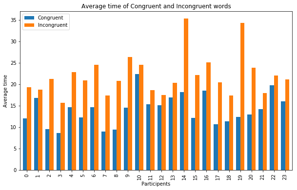

```python
# Build the visualizations here
data.plot.bar(width=0.75,figsize=(10,6))
plt.xlabel('Participents')
plt.ylabel('Average time')
plt.title('Average time of Congruent and Incongruent words')
```

(5) Now, perform the statistical test and report your results. What is your confidence level or Type I error associated with your test? What is your conclusion regarding the hypotheses you set up? Did the results match up with your expectations? **Hint:** Think about what is being measured on each individual, and what statistic best captures how an individual reacts in each environment.

The confidence level is 95%

alpha = 0.05

```python
#calculate the t-critical value
from scipy.stats import t
t.ppf(.95,24)
```

```
1.7108820799094275
```

```python
stats.ttest_ind(data.Congruent,data.Incongruent,equal_var = True)

# the differnce between 2 groups, t value = the mean of the diffrence  devided by the standard deviaton of the diffrence and the square root of the sample size

diff = data.Congruent - data.Incongruent
std_group = diff.std(axis=0)
sample_size = math.sqrt(24)
print(diff.mean(), std_group, sample_size)
```

```
-7.964791666666667 4.864826910359056 4.898979485566356
```

```python
t = diff.mean() / (std_group/sample_size)
print("The t-statistical value is: ",t)
```

```
The t-statistical value is:  -8.020706944109957
```

The critical value is 1.71088 and the t-statistics is -8.02070 is less than critical value then we reject the null hypothesis no difference between the average time in the conditions and the altrnative hypothesis is true.

t-statistic < t-critical

-8.02070 < 1.7108

References:

[1]https://machinelearningmastery.com/critical-values-for-statistical-hypothesis-testing/

[2]http://www.sthda.com/english/wiki/t-test-formula